# R tisanal code: program like a hipster

Brad Foley

05/13/2015

# Doing specific things on specific bits of data

```r
getwd()
```

```
## [1] "/media/brad/Data/Documents/softwareCarp/MCBWorkshop2015/R"
```

So far, we’ve covered basic directory and file operations in Unix. Things like moving around the file structure (cd); copying, deleting and moving files (cp, rm, mv); showing particular files (ls), and peeking into files (cat, head).

In git, we discussed version control - this entails being very careful about the files you include, and being able to trace your steps.

In Python, we spent a lot of time with manipulating data. Accesing particular bits of data, and manipulating them; as well as performing operations in loops.

Today, we’re going to build on these themes. R uses a lot of the same basic concepts, and even a lot of the same commands. Pretty much you can do all the same things - you’ll **need** to do all these same things - in R as you can in Unix or Python. Just like in git, when you do things in R you’re going to need to retrace your steps, and share your code with other people.

What R specialises in, though, is statistics and data analysis. So we’re going to focus on basic operations that will get you to your data, and help you get results out of your data.

# Topics:

- Figuring out where you are, working directories, and file navigation
  - setwd(), getwd()
  - list.files(), list.dir()
  - ?list.files()
- R data structures, and how to access elements of them
  - dataframes, lists?, arrays, matrices, vectors
  - indexes, slices, which()
- R data types, and how to convert among them
  - integers, floats, characters, boolean and factors
- read in, format, and concatenate tables
  - read.table()
  - rbind(), cbind(),
  - colnames()
  - reshape
- loops and functions
  - for loops
  - conditionals
  - functions

# Don’t work on your desktop!

First. Organise your folders from the beginning, and this includes data and analysis files. It’s a **really** good idea to have a single folder for each analysis. Data files should be .csv (with good column names).

Second. Make an intelligible readme. Explain the data, and explain every column.

Third. Make a good record of your analysis. The iPython notebooks were great. Today we’ll make a simple text-based .r file. There are a couple of things to remember in the r file: keep it clean, and comment it liberally. Save it together with your data. Use the # symbol to structure your code, and block out comments from being processed.

[figure not shown]

The first thing you’ll need to do is set the working directory. This is the address for the folder that contains your work.

To figure out where the current working directory is, you can use the following function (similar to pwd)

```r
getwd()
```

```
## [1] "/media/brad/Data/Documents/softwareCarp/MCBWorkshop2015/R"
```

**Exercise 1: Make this work on your computer**

This follows the standard R format of a function name (in this case **getwd**), followed by brackets. The brackets contain any information you need to pass to the function in order for it to work.

When we want to change the working directory to another dedicated directory, we need to use the function **setwd** (similar to cd) and include the new directory path:

```r
setwd("/media/brad/Data/Documents/softwareCarp/MCBWorkshop2015/R")
```

**Exercise 2: Make this work on your computer**

Also, note that **strings** in R are defined by quotation marks.

As in Unix, if we want to navigate up a level in the file hierarchy, we can use the command **setwd(“..”)**. Just like in the Unix command line, we can list the files in a directory using the function **list.files**. We can list all the directories in the current directory using **list.dirs**

**Exercise 3: Try moving into different directories using the setwd() function. Make sure you know where you are using getwd(). End up in the ./R directory. List the files in the subdirectory “./data_files”.**

# Reading in data

To read data from a file (the results of a gardenia-growing race, involving 3 friends), we use a function specific to the type of file. There is a general file-type reading function **read.table** and a bunch of specific ones for common file types. Check out the help menu:

```r
?read.table
```

Notice there aren’t any functions for .xlsx.

Try to read in the data:

```r
read.csv("./raw_data/gardenia.csv")
```

```
##        name   uni height leaf_number flowering_time
## 1   clarice river   12.2           8             23
## 2  hannibal   usc   24.1          16             12
## 3      bill   usc   15.7          14             13
## 4   charles  ucla    9.3           7             27
## 5  lucrecia  berk   18.1          15             12
## 6   jeffrey  berk   11.6           9             22
## 7 tamerlane  ucla   14.3          11             19
## 8   sweeney river   17.1           6             21
```

```r
print(gardenia)
```

```
## Error in print(gardenia): object 'gardenia' not found
```

You notice that this doesn’t do anything except print out the contents of the file “gardenia.csv”. The reason is, that we haven’t assigned the contents of the file to any object (a **variable**). We can create a new variable in R easily, using either **=** or **<-**

```r
gardenia = read.csv("./raw_data/gardenia.csv")

print(gardenia)
```

```
##        name   uni height leaf_number flowering_time
## 1   clarice river   12.2           8             23
## 2  hannibal   usc   24.1          16             12
## 3      bill   usc   15.7          14             13
## 4   charles  ucla    9.3           7             27
## 5  lucrecia  berk   18.1          15             12
## 6   jeffrey  berk   11.6           9             22
## 7 tamerlane  ucla   14.3          11             19
## 8   sweeney river   17.1           6             21
```

There are a few restrictions on what variables can be called (for instance, they can’t start with a number, they can’t contain spaces). But you probably want to make variable names informative, and easy to type.

You can assign **string** values to a variable, or **integers**, or **floating** point numbers. You can use these variables the same way you use any other value.

```r
A=5
B=A
#The value of B is
b
```

```
## Error in eval(expr, envir, enclos): object 'b' not found
```

```r
#Whoops!
B
```

```
## [1] 5
```

```r
#The value of A is
A
```

```
## [1] 5
```

```r
A=A*2
#A has changed
A
```

```
## [1] 10
```

```r
B
```

```
## [1] 5
```

We can see a few of these variable types using the str(), or structure function. This function is a really important one we’ll return to later. You should use it whenever you read in a new dataset.

```r
str(gardenia)
```

```
## 'data.frame':    8 obs. of  5 variables:
##  $ name          : Factor w/ 8 levels "bill","charles",..: 3 4 1 2 6 5 8 7
##  $ uni           : Factor w/ 4 levels "berk","river",..: 2 4 4 3 1 1 3 2
##  $ height        : num  12.2 24.1 15.7 9.3 18.1 11.6 14.3 17.1
##  $ leaf_number   : int  8 16 14 7 15 9 11 6
##  $ flowering_time: int  23 12 13 27 12 22 19 21
```

**Exercise 4: create a variable, and assign a number to it. Now square the value assigned to that variable using a multiplication operation on the variable**

You can also create variables that contain multiple values. If these are 1 dimensional, we call them **vectors**. We create vectors using the combine function **c**

```r
#create
dummyVector=c(4, 12, 1.3, 15, 0.1, 2.5, 7)
print(dummyVector)
```

```
## [1]  4.0 12.0  1.3 15.0  0.1  2.5  7.0
```

```r
#add to
dummyVector=c(dummyVector, 55)
print(dummyVector)
```

```
## [1]  4.0 12.0  1.3 15.0  0.1  2.5  7.0 55.0
```

```r
#create, using a range operator
rangeVector=c(1:6)
print(rangeVector)
```

```
## [1] 1 2 3 4 5 6
```

You can perform many of the same operations on vectors that you can on single values

**Exercise 5: add numbers to dummyVector. Subtract. Divide. What happens if you add a dummyVector and rangeVector? If you add a vector containing 2 numbers to dummyVector? or 3? Finally, perform a mathematical operation on dummyVector to turn all values to 1**

# Accessing data in vectors and dataframes

Remember from Python, square and round brackets have a different meaning. Like Python, we can access specific values from a vector just by referring to the position of the number, using square brackets. Pay close attention to the differences in indexing between Python and R!

```r
dummyVector
```

```
## [1]  4.0 12.0  1.3 15.0  0.1  2.5  7.0 55.0
```

```r
dummyVector[]
```

```
## [1]  4.0 12.0  1.3 15.0  0.1  2.5  7.0 55.0
```

```r
#see the difference below?
dummyVector[3]
```

```
## [1] 1.3
```

```r
#you can access indices using ranges!
dummyVector[3:6]
```

```
## [1]  1.3 15.0  0.1  2.5
```

**Exercise 6: access the 1st, 3rd, and 5th values in dummyVector (hint, you’ll need to use a vector inside the square brackets). Add 10 to only those values. What happens if you change the first variable in dummyVector to “G”?**

Vectors are flexible, but there are a few restrictions. An important thing to remember about vectors is that all the variables need to be the same type.

The same operations you can use on vectors work for dataframes. Because data frames are 2D, we need to separate the column values from the row values, and we use a comma for this. Row values come before the comma, column values after. Remember **gardenia**?

**A gardenia.**

[figure not shown]

```r
gardenia
```

```
##        name   uni height leaf_number flowering_time
## 1   clarice river   12.2           8             23
## 2  hannibal   usc   24.1          16             12
## 3      bill   usc   15.7          14             13
## 4   charles  ucla    9.3           7             27
## 5  lucrecia  berk   18.1          15             12
## 6   jeffrey  berk   11.6           9             22
## 7 tamerlane  ucla   14.3          11             19
## 8   sweeney river   17.1           6             21
```

```r
gardenia[,]
```

```
##        name   uni height leaf_number flowering_time
## 1   clarice river   12.2           8             23
## 2  hannibal   usc   24.1          16             12
## 3      bill   usc   15.7          14             13
## 4   charles  ucla    9.3           7             27
## 5  lucrecia  berk   18.1          15             12
## 6   jeffrey  berk   11.6           9             22
## 7 tamerlane  ucla   14.3          11             19
## 8   sweeney river   17.1           6             21
```

```r
#look at a single row
gardenia[1,]
```

```
##      name   uni height leaf_number flowering_time
## 1 clarice river   12.2           8             23
```

```r
#look at a single column
gardenia[,2]
```

```
## [1] river usc   usc   ucla  berk  berk  ucla  river
## Levels: berk river ucla usc
```

```r
#look at a couple columns
gardenia[,c(1,5)]
```

```
##        name flowering_time
## 1   clarice             23
## 2  hannibal             12
## 3      bill             13
## 4   charles             27
## 5  lucrecia             12
## 6   jeffrey             22
## 7 tamerlane             19
## 8   sweeney             21
```

```r
#access specific chunks
gardenia[c(1:2), (2:3)]
```

```
##     uni height
## 1 river   12.2
## 2   usc   24.1
```

Pay close attention to the way we can access particular subsets of data using vectors. This is a feature we’re going to use again and again. Another really handy feature of data frames is indexing by column names, and vectors of column names. We can access a whole column of data by referring to the column by its name.

```r
#notice that the column names are just another vector
colnames(gardenia)
```

```
## [1] "name"           "uni"            "height"         "leaf_number"
## [5] "flowering_time"
```

```r
gardenia[,"leaf_number"]
```

```
## [1]  8 16 14  7 15  9 11  6
```

```r
gardenia[,c("name", "leaf_number")]
```

```
##        name leaf_number
## 1   clarice           8
## 2  hannibal          16
## 3      bill          14
## 4   charles           7
## 5  lucrecia          15
## 6   jeffrey           9
## 7 tamerlane          11
## 8   sweeney           6
```

**Exercise 7: Some genius from Lockheed Martin measured the height of our friends’ gardenias in inches, not centimeters. Given that an inch is 2.54 cm, make a new vector called “h_cm”, in which you convert the “height” column to centimeters. Quick! Before the gardenias crash into Mars and all is lost.**

Before the next step, it is a really good time to point out that when you’re performing operations on an object, you should first create a backup (say gardenia_bup). Otherwise you have to return to the start every time you screw up. And you *will* screw up.

**Exercise 8: add the new height in centimeters column to the gardenia dataframe using column bind, or cbind(). Change the column name for “height” to reflect that one measure of height is in cm, the other in inches using colnames()**

A lot of powerful R functions take advantage of the access-by-vector methodology. For instance **order**.

```r
gardenia[,"leaf_number"]
```

```
## [1]  8 16 14  7 15  9 11  6
```

```r
order(gardenia[,"leaf_number"])
```

```
## [1] 8 4 1 6 7 3 5 2
```

**Exercise 9: Find the order of values in the gardenia “height” column. Use this resulting vector to sort the table. Print the rows containing just the 3 tallest plants**

Another function we can use in a similar way, is **which**. which() brings up an important kind of operation, the logical comparison. We use logical operators frequently, to subset data.

```r
which(gardenia[,"height"] > 10)
```

```
## [1] 1 2 3 5 6 7 8
```

```r
gardenia[,"height"] < 12
```

```
## [1] FALSE FALSE FALSE  TRUE FALSE  TRUE FALSE FALSE
```

```r
gardenia[,"name"] == "charles"
```

```
## [1] FALSE FALSE FALSE  TRUE FALSE FALSE FALSE FALSE
```

**Exercise 10: Print the rows containing just the people from USC**

# Some truthy data.

We’re now going to try out some of these fancy new tools on a much bigger dataset.

The lab of Dr. Carol Lewis focuses on the effects of selection due to parasitism in the lesser snark, *Conniptus hemifittus*. In particular, the armored plate on the head (or cephalocalypse) apparently guards the brain of the lesser snark from the piercing ovipositor of the zombigenic parasitoid beaver.

The data consists of 4 measurements: cephalocalypsis length, width and area, as well as a body size proxy - abdothorax length.

**a snark.**

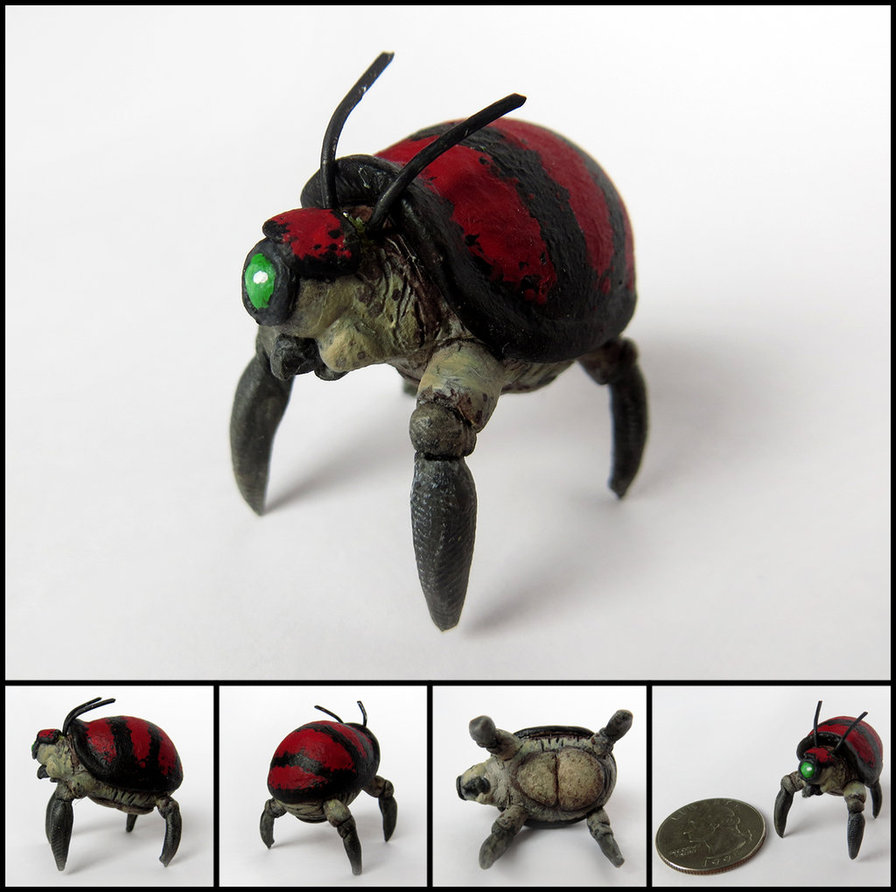

**Exercise 11: Read in both files of snark data. Stick them together using rbind and call the resulting dataset “snark”. Save it as snark.csv, in the data_file folder.**

Now we quality check. **This is really important!** The first thing we do is make sure all the data is formatted correctly. Try the **str** function on your data. What’s going on with sex?

```r
unique(snark[,"sex"])
```

```
## [1] "0"      "1"      "f"      "F"      "female" "m"      "M"      "male"
```

Other functions that are useful for checking the properties of your data include length(), nrow(), and dim(); head() and tail().

**Exercise 12: Can you change the sex coding to something sensible using which()? Save the new datafile.**

```r
str(snark)
```

[output not shown]

And now we’ll have an actual look at the data using a couple of kinds of plots. These sorts of visualisations are really helpful in picking up gross errors.

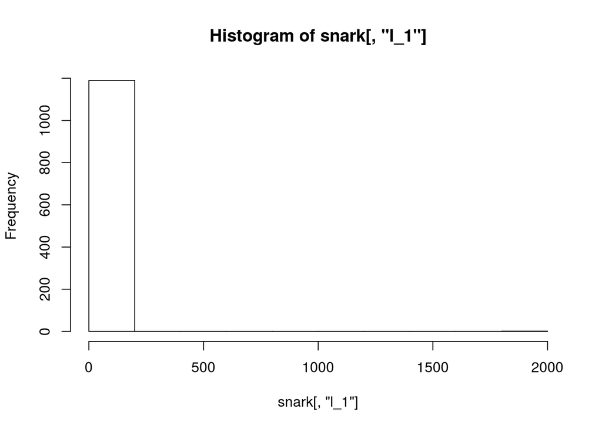

```r
hist(snark[,"l_1"])
```

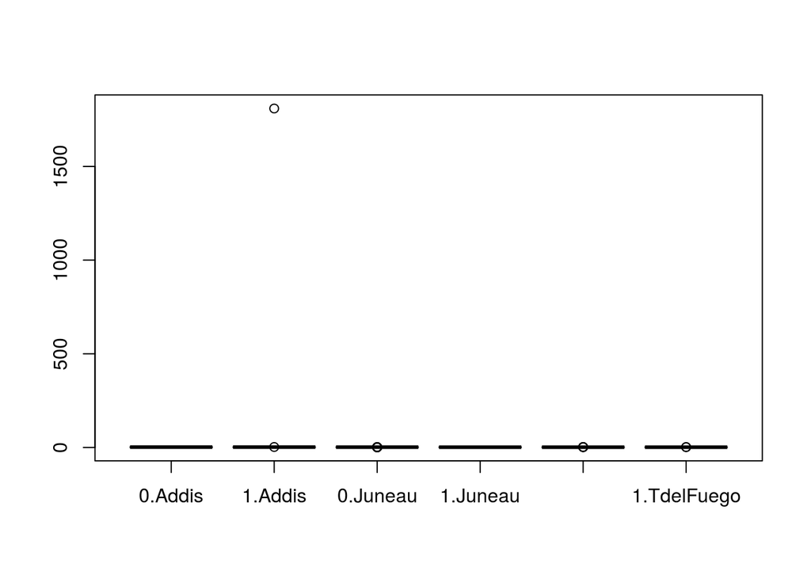

```r
#somthing is weird.
boxplot(snark[,"l_1"]~snark[,"sex"]+snark[,"pop"])
```

Notice the boxplot formula format. This is going to come up many times - it’s the general R specification for a model. A dependent variable followed by a tilde, and a nominally complicated equation with a bunch of predictors.

**Exercise 13: Let’s check for outliers using boxplot, and delete them. We can use logical operators for this.**

…and since we’re doing plots anyway, have a play with the famous plot(), and a slightly easier-to-write syntax:

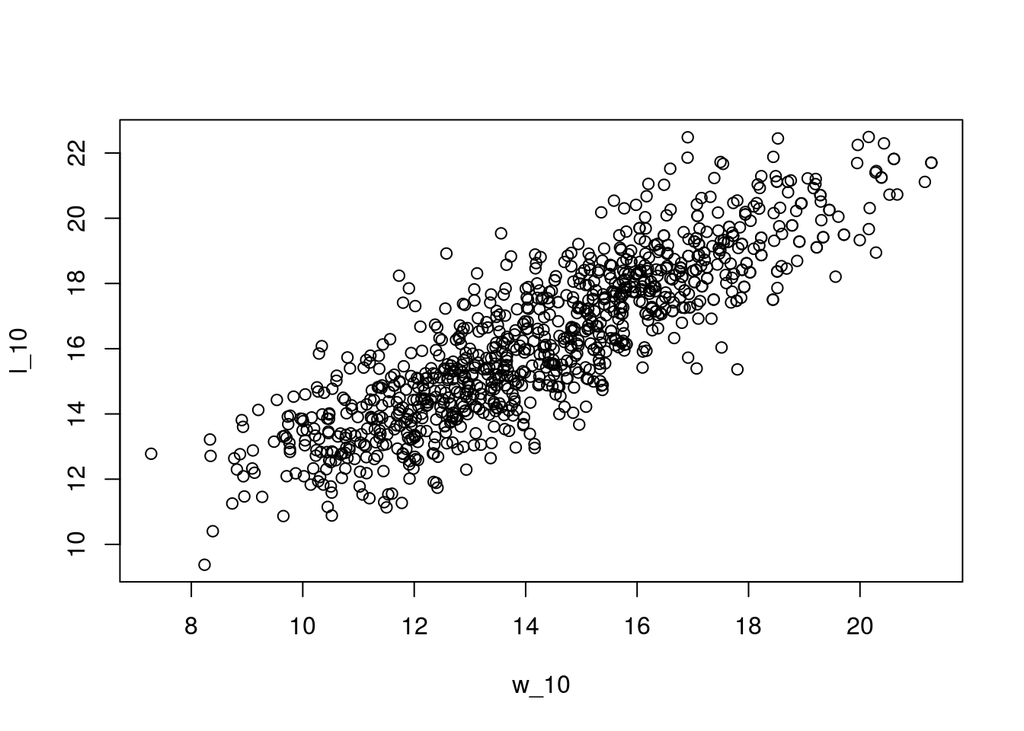

```r
plot(l_10~w_10, data=snark)
```

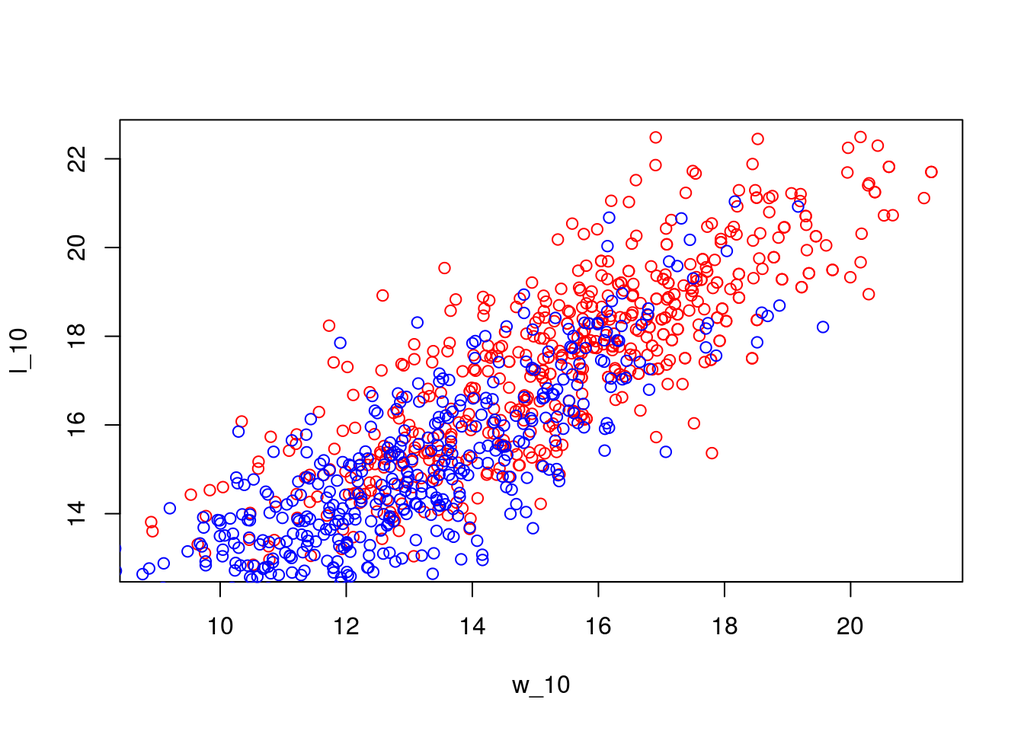

```r
plot(l_10~w_10, data=snark[which(snark[,"sex"]==0),], col="red")
points(l_10~w_10, data=snark[which(snark[,"sex"]==1),], col="blue")
```

**a zombigenic parasitoid beaver.**

[figure not shown]

**Exercise 14: the Snarks need individual id numbers. Create an id column (hint, all you need is the combine function c(), and a range). Add it to the dataset using cbind()**

# Loops

The structure of loops (and nesting in general) in R is a prefix, followed by a pair of curly brackets. For loops take a condition with a nominal index variable, and continue until the index reaches a set point. Notice, you don’t have to do anything to the index variable.

The syntax is pretty similar to Python syntax. Also notice, even though R doesn’t care if you indent, you should *always* use standard nested indentation for multi-line commands using brackets.

```r
for(i in 1:10){
  print(i)
}
```

```
## [1] 1
## [1] 2
## [1] 3
## [1] 4
## [1] 5
## [1] 6
## [1] 7
## [1] 8
## [1] 9
## [1] 10
```

```r
Sentence="Hello, I'm on loop number"
for(i in 1:20){
  output=paste(Sentence, i)
  print(output)
  }
```

```
## [1] "Hello, I'm on loop number 1"
## [1] "Hello, I'm on loop number 2"
## [1] "Hello, I'm on loop number 3"
## [1] "Hello, I'm on loop number 4"
## [1] "Hello, I'm on loop number 5"
## [1] "Hello, I'm on loop number 6"
## [1] "Hello, I'm on loop number 7"
## [1] "Hello, I'm on loop number 8"
## [1] "Hello, I'm on loop number 9"
## [1] "Hello, I'm on loop number 10"
## [1] "Hello, I'm on loop number 11"
## [1] "Hello, I'm on loop number 12"
## [1] "Hello, I'm on loop number 13"
## [1] "Hello, I'm on loop number 14"
## [1] "Hello, I'm on loop number 15"
## [1] "Hello, I'm on loop number 16"
## [1] "Hello, I'm on loop number 17"
## [1] "Hello, I'm on loop number 18"
## [1] "Hello, I'm on loop number 19"
## [1] "Hello, I'm on loop number 20"
```

# Data summarizing.

R has a bunch of built in functions to summarise data, like max, min, mean and sd (standard deviation). We can apply these to columns (R is a little picky about how you apply functions to rows). So we can find out, for instance, what the size of the largest snark on day 13 is using

```r
max(snark[,"bod_13"])
```

```
## [1] NA
```

```r
#whoops!
max(snark[,"bod_13"], na.rm=T)
```

```
## [1] 9276.299
```

**Exercise 15: Use a for-loop, and print max() and mean() summaries for all measurements for all days**

Before we go any further, it’s critical that we get the data into the right *shape*. By this we mean one row, one observation. Almost any analysis we do (for instance, regression across time) will require this format. While Drs Lewis and Bellman entered the data by individual, we need to reshape the data for such that each day is a row (so-called long format).

To do that, we use a handy function called reshape. We can specify our

- *data* (snark)
- the portion of data that’s varying c(5:length(snark))
- the *direction* (“long”) the variables we’re grouping by
- *idvar* (id)
- *timevar* a (string) name for the column that corresponds with the time variable (say, “day”)
- importantly, *sep* value, so that reshape can parse the column names

**Exercise 16: reshape the data, call it snarkLong**

Now we can do cool things like:

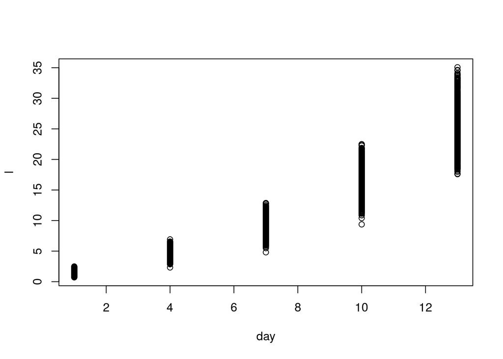

```r
plot(l~day, data=snarkLong)
```

If we want to do hypothesis testing, one of the most basic tools we have is linear regression. It turns out, this is really easy to do in R. You use the same syntax as with the boxplot, but the function is called **lm**. Linear modelling is able to handle both categorical and quantitative data.

```r
sexSize=lm(bod~sex, data=snarkLong[which(snarkLong[,"day"]==13),])
summary(sexSize)
```

```
##
## Call:
## lm(formula = bod ~ sex, data = snarkLong[which(snarkLong[, "day"] ==
##     13), ])
##
## Residuals:
##     Min      1Q  Median      3Q     Max
## -2471.4  -809.3  -135.8   688.7  6389.9
##
## Coefficients:
##             Estimate Std. Error t value Pr(>|t|)
## (Intercept)  2886.39      72.88   39.61   <2e-16 ***
## sex1        -1909.62     109.19  -17.49   <2e-16 ***
## ---
## Signif. codes:  0 '***' 0.001 '**' 0.01 '*' 0.05 '.' 0.1 ' ' 1
##
## Residual standard error: 1684 on 961 degrees of freedom
##   (107 observations deleted due to missingness)
## Multiple R-squared:  0.2414, Adjusted R-squared:  0.2407
## F-statistic: 305.9 on 1 and 961 DF,  p-value: < 2.2e-16
```

```r
cephGrow=lm(a~day, data=snarkLong)
summary(cephGrow)
```

```
##
## Call:
## lm(formula = a ~ day, data = snarkLong)
##
## Residuals:
##     Min      1Q  Median      3Q     Max
##  -41.12  -12.84   -3.88   10.87 1436.40
##
## Coefficients:
##              Estimate Std. Error t value Pr(>|t|)
## (Intercept) -16.81975    0.72822   -23.1   <2e-16 ***
## day           6.96717    0.09072    76.8   <2e-16 ***
## ---
## Signif. codes:  0 '***' 0.001 '**' 0.01 '*' 0.05 '.' 0.1 ' ' 1
##
## Residual standard error: 27.47 on 5170 degrees of freedom
##   (178 observations deleted due to missingness)
## Multiple R-squared:  0.5329, Adjusted R-squared:  0.5328
## F-statistic:  5898 on 1 and 5170 DF,  p-value: < 2.2e-16
```

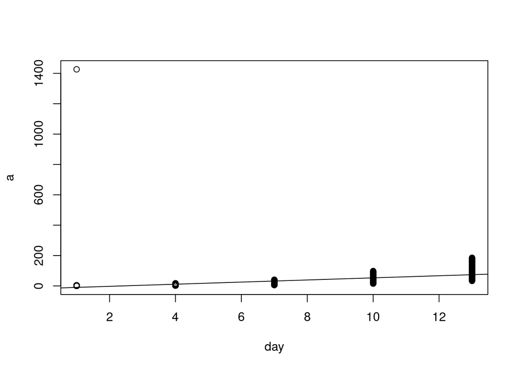

```r
plot(a~day, data=snarkLong)
abline(cephGrow)
```

**Exercise 17: write linear models to test whether there is variation in growth rate of body and cephalocalypse by sex, population and family**

# Doing more than one thing at a time

So far, we’ve only been looking at one or two variables at a time. If we wanted to lots of tests, or lots of summaries on the data, we could use for loops. It turns out that for loops in R can be very slow. But happily there is a powerful, flexible tool in R for applying a number of arbitrary functions across an arbitrary number of grouping variables. The package is called plyr, and the function is ddply.

For instance, if we want to get our mean, max, and min summaries for the sexes separately using ddply:

```r
library(plyr)
sexSum=ddply(snarkLong, .(sex, day), summarise,
             N= length(bod),
             aMean=mean(a, na.rm=T),
             aRat=mean(a, na.rm=T)/mean(bod, na.rm=T))

sexSum
```

```
##    sex day   N     aMean       aRat
## 1    0   1 567  1.367988 0.05526520
## 2    0   4 567  7.188322 0.05435167
## 3    0   7 567 19.751634 0.04662100
## 4    0  10 567 50.192990 0.03967613
## 5    0  13 567 99.762279 0.03456303
## 6    1   1 503  4.002708 0.19941625
## 7    1   4 503  5.886829 0.08753044
## 8    1   7 503 15.084267 0.08554256
## 9    1  10 503 37.918357 0.08133553
## 10   1  13 503 76.396059 0.07821350
```

**Exercise 18: summarise n, mean, min, max, sd, area, and cephalocalypse:body ratio by sex, population and day**

# The full flexibility of doing particular things to particular stuff requires you to write your own functions…

So far, we’ve talked about, and used a lot of functions, but haven’t looked at them carefully. We haven’t needed to, because R has so many useful built in functions, and libraries of other functions we can download and use. But even with all of this, we’re quickly going to find we need something that someone else hasn’t written. And for that, we need to write our own.

Fortunately, this isn’t too hard. We just need to keep track of what we’re putting into the function, and what we’re taking out. And what we’re leaving behind.

- putting in: ALL the things, and ONLY the things you’re going to use in the function
- taking out: a single result.
- functions are like Vegas: whatever happens in a function, stays in a function. Nothing outside the function changes, except what you pass out.

The way to define a function is pretty simple. It just needs a name, and a list of the required arguments. One other required element is a return value - the result of the function.

```r
gardeniaGrowth=function(sun, name, gardenia){
  height=gardenia[which(gardenia[,"name"]==name),"height"]
  newGrowth=height*sun
  newHeight=newGrowth+height
  return(newHeight)
}

clariceGrowth=gardeniaGrowth(2.1, "clarice", gardenia)
hannibalGrowth=gardeniaGrowth(2, "hannibal", gardenia)
lucreciaGrowth=gardeniaGrowth(1.5, "lucrecia", gardenia)

print(clariceGrowth)
```

```
## [1] 37.82
```

```r
print(hannibalGrowth)
```

```
## [1] 72.3
```

```r
print(lucreciaGrowth)
```

```
## [1] 45.25
```

```r
print(newHeight)
```

```
## Error in print(newHeight): object 'newHeight' not found
```

# Exercise 19: write a function that, for a given sex and family, calculates the mean rate of growth as the ratio between the (average) initial size, and the (average) change in size between the first and last day.

```r
growthRate=function(day1_data, day13_data){
  #??????
  #??????
}
```